# GFA-Evaluation & GFA-Grünflächen-Configurator - Manual

Author

Gewerd Strauss

Published

07.09.2023

# 1 Grünflächen-Konfigurator

To make things easier, I will establish a few rules used throughout this section.  
Anytime text is formatted `like this (X)`, it refers to a button, editable field, drop-down menu, or in general a control on the GUI. The number at the end, here an `(X)` signifies which section of the GUI this control is located in. As an example, `csv2xlsx (4)` is the button used to convert *csv*-files to *xlsx*-files, located under *4. Auxiliary Utilities*.

### 1.0.2 Editing a configuration

First off it makes sense to take a look at the example configurations and how the results of them look. Examples can be found under `XX\res\Examples`, where `XX` is the folder in which this program resides. They are not meant to display sensible data, the data may be unrealistic. The intention of the reference files is mostly to give simple visualisation of a configuration. They also don’t showcase all potential cases, as those are just too many.

1. replace the cell-delimiter (`,` or `;`) with `;`
2. replace dots `.` with `,`
3. save this transformed version **to the csv-file**, effectively overwriting it.
4. Afterwards, it will create an xlsx-copy.  
   **This functionality requires the program Excel to be installed on the user’s machine, as it takes advantage of Excel’s *ComObject*-Interface to do its work**.

*Program Configuration options*:  
As with all *program*-configuration options, these affect the behaviour of the Configurator-Program, **not** the R-Script.  
Options can be accessed by pressing *Alt+P* on the Configurator’s main window. It is not recommended to modify the raw config files of this program by hand.[^1]

<sup>1</sup> You can, obviously. It is just very easy to disrupt or destroy data if you do not know how AutoHotKey handles config files, and more importantly how this program itself handles them. Just use the GUI please.

| Option | Explanation |
| --- | --- |
| / | / |

## 1.1 Rename images

Upon submission, the program will open a preview in which the user can check that each image was associated with its correct name; then submit to rename the images.

Images are never renamed in-place, instead a set of working copies is made which get renamed instead. They will be located in a *GFAR_WD*-subfolder of the initially chosen directory, alongside a textfile associating original filenames with their renamed counterparts.  
As with all *program*-configuration options, these affect the behaviour of the Configurator-Program, **not** the R-Script.  
Options can be accessed by pressing *Alt+P* on the Configurator’s main window. It is not recommended to modify the raw config files of this program by hand.[^2]

<sup>2</sup> You can, obviously. It is just very easy to disrupt or destroy data if you do not know how AutoHotKey handles config files, and more importantly how this program itself handles them. Just use the GUI please.

| Option | Explanation |
| --- | --- |
| filetype | Select if the script should consider *JPG*- or *PNG*-files for renaming. |
| PutFilesOnClipboard | Do you want to have the renamed images put on your clipboard at the end? Suggested if you need to move them all to a different computer. |
| CopyFiles | Select if you want to copy `Ctrl+C` the files to your clipboard. Uncheck if you want to cut `Ctrl+X` them instead |
| CopyParentDirectory | Select if you want to copy/cut the parent directory, instead of all files. Generally suggested to ease batch-renaming of multiple sets at once. |

## 1.2 Parameter Quick-Reference

This section serves as a quick reference for modifying an existing config-file without necessarily opening the program, and assumes the user is informed about the basic functionality of the parameters they alter.  
If unsure, it is recommended to modify config files via this script - although that is only possible on Windows.  
For further, and particularly usage-dependent information, see the tooltip information on each parameter.

### 1.2.1 1. Grouping

#### `Facet2D`

| Parameter | `Facet2D` [Section:`Experiment`] |
| --- | --- |
| Value | `FALSE` |
| Default | `0` |
| Type | `boolean` |
| Options | `TRUE/FALSE` |
| Instruction | `Facet2D: Do you want to facet the plot, f.e. over a treatment?` |
| Elaboration | `Clarification: Facetting here refers to the segmentation of the plots along the Y-Axis, NOT along the X-Axis.\nFor segmenting along the X-Axis, refer to 'UniqueGroups' and 'GroupsOrderX'.` |

#### `Facet2DVar`

| Parameter | `Facet2DVar` [Section:`Experiment`] |
| --- | --- |
| Value | `/` |
| Default | `/` |
| Type | `String` |
| Options | `/` |
| Instruction | `Facet2DVar: Set the comma-separated list of facet-members to assing to the 'UniqueGroups'` |
| Elaboration | `[Facet2D==TRUE]\nClarification: The entries you specified for 'UniqueGroups' must each match a single entry in this list as well` |

#### `GroupsOrderX`

| Parameter | `GroupsOrderX` [Section:`Experiment`] |
| --- | --- |
| Value | `UU,G14,G21,G28,G35,G42` |
| Default | `UU,G14,G21,G28,G35,G42` |
| Type | `String` |
| Options | `/` |
| Instruction | `GroupsOrderX: Set the comma-separated order of groups in the plots along X-axis` |
| Elaboration | `Order the Groups along the X-Axis. Groups are ordered left to right` |

#### `GroupsOrderY`

| Parameter | `GroupsOrderY` [Section:`Experiment`] |
| --- | --- |
| Value | `/` |
| Default | `/` |
| Type | `String` |
| Options | `/` |
| Instruction | `GroupsOrderY: Set the comma-separated order of groups in the plots along Y-Axis (only for facetting)` |
| Elaboration | `[Facet2D==TRUE]\nOrder the Groups along the Y-Axis. Groups are ordered top to bottom.` |

#### `Palette_Boxplot`

| Parameter | `Palette_Boxplot` [Section:`Experiment`] |
| --- | --- |
| Value | `yellow,orange,orangered,red,darkred,black,white` |
| Default | `yellow,orange,orangered,red,darkred,black,white` |
| Type | `String` |
| Options | `w400/` |
| Instruction | `Palette_Boxplot: Set the colors for the Summaryplot` |
| Elaboration | `Colors are assigned regardless of order of the plots, and always in the following order:\nLeft to right, Top to bottom\n\nThis set of colors is responsible for the overview plot` |

#### `Palette_Boxplot2`

| Parameter | `Palette_Boxplot2` [Section:`Experiment`] |
| --- | --- |
| Value | `white,yellow,orange,orangered,red,darkred,black` |
| Default | `white,yellow,orange,orangered,red,darkred,black` |
| Type | `String` |
| Options | `w400/` |
| Instruction | `Palette_Boxplot2: Set the colors for the daily plots` |
| Elaboration | `Colors are assigned regardless of order of the plots, and always in the following order:\nLeft to right, Top to bottom\n\nThis set of colors is responsible for the daily plots` |

#### `Palette_Lines`

| Parameter | `Palette_Lines` [Section:`Experiment`] |
| --- | --- |
| Value | `yellow,orange,orangered,red,darkred,black,black` |
| Default | `yellow,orange,orangered,red,darkred,black,black` |
| Type | `String` |
| Options | `w400/` |
| Instruction | `Palette_Lines: Set the colors for the Summaryplot` |
| Elaboration | `Colors are assigned regardless of order of the plots, and always in the following order:\nLeft to right, Top to bottom\n\nThis set of colors is responsible for the overview plot` |

#### `Palette_Lines2`

| Parameter | `Palette_Lines2` [Section:`Experiment`] |
| --- | --- |
| Value | `black,yellow,orange,orangered,red,darkred,black` |
| Default | `black,yellow,orange,orangered,red,darkred,black` |
| Type | `String` |
| Options | `w400/` |
| Instruction | `Palette_Lines2: Set the colors for the daily plots` |
| Elaboration | `Colors are assigned regardless of order of the plots, and always in the following order:\nLeft to right, Top to bottom\n\nThis set of colors is responsible for the daily plots` |

#### `PotsPerGroup`

| Parameter | `PotsPerGroup` [Section:`Experiment`] |
| --- | --- |
| Value | `7` |
| Default | `7` |
| Type | `Integer` |
| Options | `number/` |
| Instruction | `PotsPerGroup: Set the number of pots per group/combination` |
| Elaboration | `[Facet2D==TRUE]\nHere, combination is a combination of a member of 'UniqueGroups' and a member of 'Facet2DVar'` |

#### `RefGroup`

[output not shown]

#### `UniqueGroups`

| Parameter | `UniqueGroups` [Section:`Experiment`] |
| --- | --- |
| Value | `G14,G21,G28,G35,G42,UU` |
| Default | `G14,G21,G28,G35,G42,UU` |
| Type | `String` |
| Options | `/` |
| Instruction | `UniqueGroups: Set the comma-separated list of all unique group names` |
| Elaboration | `If you set 'Facet2D' to TRUE, this must have as many entries as 'Facet2DVar'` |

### 1.2.2 2. GeneralConfiguration

#### `Debug`

| Parameter | `Debug` [Section:`General`] |
| --- | --- |
| Value | `FALSE` |
| Default | `0` |
| Type | `boolean` |
| Options | `TRUE/FALSE` |
| Instruction | `Debug: Do you want to print debug information?` |
| Elaboration |  |

#### `filename_date_format`

| Parameter | `filename_date_format` [Section:`Experiment`] |
| --- | --- |
| Value | `%d.%m.%Y` |
| Default | `%d.%m.%Y` |
| Type | `String` |
| Options | `%d.%m.%Y\|\|%Y-%m-%d` |
| Instruction | `filename_date_format: Select the date format for saved files. Editing allowed` |
| Elaboration | `Does not control the date format on the figure. For that, see option 'figure_date_format'.` |

#### `Filename_Prefix`

[output not shown]

#### `language`

| Parameter | `language` [Section:`General`] |
| --- | --- |
| Value | `English` |
| Default | `English` |
| Type | `String` |
| Options | `English\|\|German` |
| Instruction | `language: Select language for auto-generated labels` |
| Elaboration |  |

#### `Normalise`

| Parameter | `Normalise` [Section:`Experiment`] |
| --- | --- |
| Value | `TRUE` |
| Default | `1` |
| Type | `boolean` |
| Options | `TRUE/FALSE` |
| Instruction | `Normalise: Do you want to normalise your leaf area?` |
| Elaboration | `This accesses the data-column 'plant_area_normalised'. For more info, check the documentation.` |

#### `T0`

| Parameter | `T0` [Section:`Experiment`] |
| --- | --- |
| Value | `20230906111832` |
| Default | `20230906111832` |
| Type | `String` |
| Options | `/` |
| Instruction | `T0: Set the T0-date for calculating 'plant-age' for your experiment, in format dd.MM.yyyy (24.12.2023)` |
| Elaboration | `This is relevant mostly for calculating the plant-age plotted on the y-axis.` |

#### `used_filesuffix`

| Parameter | `used_filesuffix` [Section:`General`] |
| --- | --- |
| Value | `xlsx` |
| Default | `xlsx` |
| Type | `String` |
| Options | `xlsx\|\|csv` |
| Instruction | `used_filesuffix: Select the filetype you want to ingest` |
| Elaboration | `'xlsx' is recommended. 'csv' was tested, but not as adamantly as xlsx. It should not make any difference, but that is not guaranteed.` |

### 1.2.3 3. Figure

#### `Name`

| Parameter | `Name` [Section:`Experiment`] |
| --- | --- |
| Value | `Experiment X` |
| Default | `Experiment X` |
| Type | `String` |
| Options | `/` |
| Instruction | `Name: Set the name of the Experiment as seen in the figure title` |
| Elaboration |  |

#### `PlotMeanLine`

| Parameter | `PlotMeanLine` [Section:`General`] |
| --- | --- |
| Value | `TRUE` |
| Default | `1` |
| Type | `boolean` |
| Options | `TRUE/FALSE` |
| Instruction | `PlotMeanLine: Do you want to plot the line connecting the means of each group's boxplots?` |
| Elaboration |  |

#### `Theme`

| Parameter | `Theme` [Section:`General`] |
| --- | --- |
| Value | `7` |
| Default | `7` |
| Type | `Integer` |
| Options | `Number` |
| Instruction | `Theme: Choose your default theme.` |
| Elaboration |  |

### 1.2.4 4. Axes

#### `axis_units_x`

| Parameter | `axis_units_x` [Section:`General`] |
| --- | --- |
| Value | `Tage,days` |
| Default | `Tage,days` |
| Type | `String` |
| Options | `/` |
| Instruction | `axis_units_x: Set the unit of the X-axis (for the Overview-plot).` |
| Elaboration | `Format: '[German Text],[English Text]'. Replace a field with "/" to skip it` |

#### `axis_units_x_Daily`

| Parameter | `axis_units_x_Daily` [Section:`General`] |
| --- | --- |
| Value | `/,/` |
| Default | `/,/` |
| Type | `String` |
| Options | `/` |
| Instruction | `axis_units_x_Daily: Set the unit of the X-axis (for the daily plots).` |
| Elaboration | `Format: '[German Text],[English Text]'. Replace a field with "/" to skip it` |

#### `axis_units_y`

| Parameter | `axis_units_y` [Section:`General`] |
| --- | --- |
| Value | `cm^2,cm^2` |
| Default | `cm^2,cm^2` |
| Type | `String` |
| Options | `/` |
| Instruction | `axis_units_y: Set the unit of the Y-axis (for the Overview-plot).` |
| Elaboration | `Format: '[German Text],[English Text]'. Replace a field with "/" to skip it` |

#### `axis_units_y_Daily`

| Parameter | `axis_units_y_Daily` [Section:`General`] |
| --- | --- |
| Value | `cm^2,cm^2` |
| Default | `cm^2,cm^2` |
| Type | `String` |
| Options | `/` |
| Instruction | `axis_units_y_Daily: Set the unit of the Y-axis (for the daily plots).` |
| Elaboration | `Format: '[German Text],[English Text]'. Replace a field with "/" to skip it` |

#### `BreakStepSize`

| Parameter | `BreakStepSize` [Section:`Experiment`] |
| --- | --- |
| Value | `25` |
| Default | `25` |
| Type | `number` |
| Options | `/` |
| Instruction | `BreakStepSize: Set the spacing between numbered breaks on the Y-Axis. Requires ForceAxes=T` |
| Elaboration |  |

#### `figure_date_format`

[output not shown]

#### `ForceAxes`

| Parameter | `ForceAxes` [Section:`Experiment`] |
| --- | --- |
| Value | `FALSE` |
| Default | `0` |
| Type | `boolean` |
| Options | `TRUE/FALSE` |
| Instruction | `ForceAxes: Do you want to force the Y-Axis scaling? This requires setting 'YLimits'` |
| Elaboration |  |

#### `RelativeColnames`

| Parameter | `RelativeColnames` [Section:`General`] |
| --- | --- |
| Value | `TRUE` |
| Default | `1` |
| Type | `boolean` |
| Options | `TRUE/FALSE` |
| Instruction | `RelativeColnames: Do you want to display the X-positions as 'days since T0'?` |
| Elaboration |  |

#### `ShowBothColnames`

| Parameter | `ShowBothColnames` [Section:`General`] |
| --- | --- |
| Value | `FALSE` |
| Default | `0` |
| Type | `boolean` |
| Options | `TRUE/FALSE` |
| Instruction | `ShowBothColnames: Do you want to display the X-positions as 'days since T0 - date'?` |
| Elaboration |  |

#### `XLabel`

| Parameter | `XLabel` [Section:`Experiment`] |
| --- | --- |
| Value | `Time since repotting` |
| Default | `Time since repotting` |
| Type | `String` |
| Options | `/` |
| Instruction | `XLabel: Set the xlabel-string for the summary plot.` |
| Elaboration |  |

#### `XLabel_Daily`

| Parameter | `XLabel_Daily` [Section:`Experiment`] |
| --- | --- |
| Value | `Treatment Groups` |
| Default | `Treatment Groups` |
| Type | `String` |
| Options | `/` |
| Instruction | `XLabel_Daily: Set the xlabel-string for the daily analyses.` |
| Elaboration |  |

#### `YLabel`

| Parameter | `YLabel` [Section:`Experiment`] |
| --- | --- |
| Value | `green plant area` |
| Default | `green plant area` |
| Type | `String` |
| Options | `/` |
| Instruction | `YLabel: Set the ylabel-string for the summary plot and daily analyses.` |
| Elaboration |  |

#### `YLimits`

| Parameter | `YLimits` [Section:`Experiment`] |
| --- | --- |
| Value | `0,150` |
| Default | `0,150` |
| Type | `String` |
| Options | `/` |
| Instruction | `YLimits: Set the minimum and maximum limit for the Y-Axis. Does not take effect if 'ForceAxes' is false. Used for all plots` |
| Elaboration |  |

### 1.2.5 5. Statistics and its displaying

#### `PlotSampleSize`

| Parameter | `PlotSampleSize` [Section:`General`] |
| --- | --- |
| Value | `TRUE` |
| Default | `1` |
| Type | `boolean` |
| Options | `TRUE/FALSE` |
| Instruction | `PlotSampleSize: Do you want to plot the sample size of each group's boxplots?` |
| Elaboration |  |

#### `ShowNAtallboxplots`

[output not shown]

#### `ShowOnlyIrregularN`

| Parameter | `ShowOnlyIrregularN` [Section:`General`] |
| --- | --- |
| Value | `TRUE` |
| Default | `1` |
| Type | `boolean` |
| Options | `TRUE/FALSE` |
| Instruction | `ShowOnlyIrregularN: Do you want to only plot sample sizes which differ from 'PotsPerGroup'?` |
| Elaboration | `Requires also ticking 'PlotSampleSize'` |

### 1.2.6 6. Fontsizes

#### `Fontsize_PValue`

| Parameter | `Fontsize_PValue` [Section:`Fontsizes`] |
| --- | --- |
| Value | `2.500000` |
| Default | `2.5` |
| Type | `number` |
| Options | `/` |
| Instruction | `Fontsize_PValue: Set the fontsize for the p-values in the daily plots` |
| Elaboration | `Note that the zeros can be omitted in principle, but are a side-effect of the validation used. You can ignore them.` |

#### `Fontsize_SampleSize`

| Parameter | `Fontsize_SampleSize` [Section:`Fontsizes`] |
| --- | --- |
| Value | `2.500000` |
| Default | `2.5` |
| Type | `number` |
| Options | `/` |
| Instruction | `Fontsize_SampleSize: Set the fontsize for the sample size in the daily plots` |
| Elaboration | `Note that the zeros can be omitted in principle, but are a side-effect of the validation used. You can ignore them.` |

### 1.2.7 7. Titles

#### `DebugText`

| Parameter | `DebugText` [Section:`General`] |
| --- | --- |
| Value | `"Setting [DEBUG==TRUE]" in section '2. General Configuration' will overwrite any settings made in this section"` |
| Default | `"Setting [DEBUG==TRUE]" in section '2. General Configuration' will overwrite any settings made in this section"` |
| Type | `text` |
| Options | `/` |
| Instruction | `Setting [DEBUG==TRUE] in section '2. General Configuration' will overwrite any settings made in this section` |
| Elaboration |  |

#### `ShowTitle`

| Parameter | `ShowTitle` [Section:`General`] |
| --- | --- |
| Value | `FALSE` |
| Default | `0` |
| Type | `boolean` |
| Options | `TRUE/FALSE` |
| Instruction | `ShowTitle: Do you want to show the title above the summary plot?` |
| Elaboration |  |

#### `ShowTitle_Daily`

| Parameter | `ShowTitle_Daily` [Section:`General`] |
| --- | --- |
| Value | `FALSE` |
| Default | `0` |
| Type | `boolean` |
| Options | `TRUE/FALSE` |
| Instruction | `ShowTitle_Daily: Do you want to show the title above the daily plots?` |
| Elaboration |  |

#### `ShowTitleDateWhere`

| Parameter | `ShowTitleDateWhere` [Section:`General`] |
| --- | --- |
| Value | `SubTitle` |
| Default | `SubTitle` |
| Type | `String` |
| Options | `Title\|SubTitle\|\|nowhere` |
| Instruction | `ShowTitleDateWhere: Select if the date (range) should be appended to the end of the title- or subtitle-element.` |
| Elaboration | `For date-format, see key 'figure_date_format' under section '4. Axes'\n\n[ShowTitle==FALSE]\nNo effect.` |

#### `ShowTitleSub`

| Parameter | `ShowTitleSub` [Section:`General`] |
| --- | --- |
| Value | `FALSE` |
| Default | `0` |
| Type | `boolean` |
| Options | `TRUE/FALSE` |
| Instruction | `ShowTitleSub: Do you want to show the sub-title above the summary plot?` |
| Elaboration |  |

#### `ShowTitleSub_Daily`

| Parameter | `ShowTitleSub_Daily` [Section:`General`] |
| --- | --- |
| Value | `FALSE` |
| Default | `0` |
| Type | `boolean` |
| Options | `TRUE/FALSE` |
| Instruction | `ShowTitleSub_Daily: Do you want to show the sub-title above the daily plots?` |
| Elaboration |  |

#### `Title`

| Parameter | `Title` [Section:`General`] |
| --- | --- |
| Value | `/` |
| Default | `/` |
| Type | `String` |
| Options | `/` |
| Instruction | `Title: Enter the title you want to use for the summary plot. Leave empty to use the default title.` |
| Elaboration | `Note that the respective days' date is appended to either the title or subtitle, depending on what you choose under 'ShowTitleDateWhere'.` |

#### `Title_Daily`

| Parameter | `Title_Daily` [Section:`General`] |
| --- | --- |
| Value | `/` |
| Default | `/` |
| Type | `String` |
| Options | `/` |
| Instruction | `Title_Daily: Enter the title you want to use for the daily plots. Leave empty to use the default title.` |
| Elaboration | `Note that the respective days' date is appended to either the title or subtitle, depending on what you choose under 'ShowTitleDateWhere'.` |

#### `TitleSub`

| Parameter | `TitleSub` [Section:`General`] |
| --- | --- |
| Value | `/` |
| Default | `/` |
| Type | `String` |
| Options | `/` |
| Instruction | `TitleSub: Enter the sub-title you want to use for the summary plot. Leave empty to use the default sub-title.` |
| Elaboration | `Note that the respective days' date is appended to either the title or subtitle, depending on what you choose under 'ShowTitleDateWhere'.` |

#### `TitleSub_Daily`

| Parameter | `TitleSub_Daily` [Section:`General`] |
| --- | --- |
| Value | `/` |
| Default | `/` |
| Type | `String` |
| Options | `/` |
| Instruction | `TitleSub_Daily: Enter the sub-title you want to use for the daily plots. Leave empty to use the default sub-title.` |
| Elaboration | `Note that the respective days' date is appended to either the title or subtitle, depending on what you choose under 'ShowTitleDateWhereA'.` |

# 2 GFA_Evaluation.R

## 2.1 Setup

The script can also be used without the configurator explained so far.

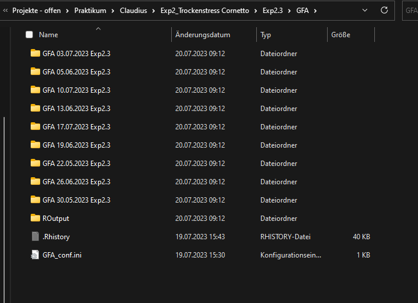

Example folder structure. The names of the folders do not matter. Note the file ‘GFA_conf.ini’ in the directory. This configures the behaviour of the script and is necessary to run the script.

Below you will find an example script

## 2.2 Results

```r
# do not run, show
get_os <- function(){
    sysinf <- Sys.info()
    if (!is.null(sysinf)){
        os <- sysinf['sysname']
        if (os == 'Darwin')
            os <- "osx"
    } else { ## mystery machine
        os <- .Platform$OS.type
        if (grepl("^darwin", R.version$os))
            os <- "osx"
        if (grepl("linux-gnu", R.version$os))
            os <- "linux"
    }
    return(tolower(os))
}
source("D:/Dokumente neu/Repositories/Grünflächen-Utilities/GFA_Evaluation.R")
if (isTRUE(as.logical(get_os()=='windows'))) { # this is an optimistic approach to the problem, I won't try to anticipate all possible OS-names # WINDOWS:
    GFA_2 <- GFA_main(folder_path = r"(D:\Dokumente neu\Obsidian NoteTaking\The Universe\200 University\06 Interns and Unis\BE28 Internship Report\assets\Exp2.3\GFA\GFA_conf.ini)",returnDays = 0,saveFigures = 0,saveExcel = 0,saveRDATA = 0)
} else {    # MAC:
    GFA_2 <- GFA_main(folder_path = r"(D:\Dokumente neu\Obsidian NoteTaking\The Universe\200 University\06 Interns and Unis\BE28 Internship Report\assets\Exp2.3\GFA\GFA_conf.ini)",returnDays = 0,saveFigures = 0,saveExcel = 0,saveRDATA = 0)
}
## do not clear your workspace between the calls to `source()` and `GFA_main()`. If you absolutely MUST, only clear your worspace after GFA_main() has returned its output and you no longer need its results, or selectively clear variables. Clearing the workspace inbetween these two points will render the script useless.
```

Which results in the following plot

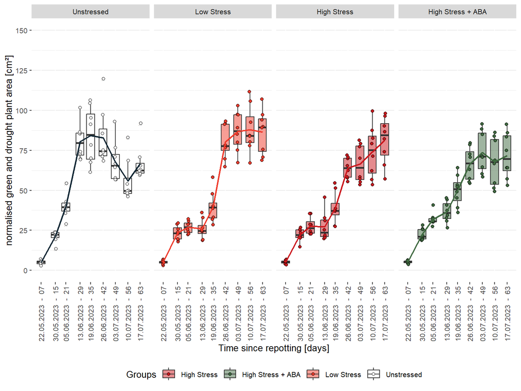

## 2.3 Error Handling and restrictions

Most aspects of the R-Script are handled on a trust-first basis, but certain things are validated as required. If checks are not passed, the script will stop by throwing a distinct *error*-message (red text in Console). In this case, the issue *must* be resolved to allow the script to function.  
There are also notifications which are displayed as *warnings* (yellow text). These contain information on internal deviations to the given configurations, or generally inform the user that something might behave different than the settings would indicate. The difference here is that they are performed automatically, are conservative and usually required to obtain acceptable results.

```r
Error: GFA_main() [user-defined]: Task: loading configuration from ini-file,1
The configuration file ('C:\Users\Claudius Main\Desktop\TempTemporal\Exp2.3_GFA_fixedValuesfor1007\GFA_conf.ini')
could not be loaded. The best assumption for its file-encoding is UTF-16LE, but using this returned an empty object.
Please double-check the encoding of the configuration-file
```

Beyond this, by functionality this script does not deviate from the steps taken in the original script this was derived from.

# 3 Requirements

Full functionality requires:

- `GFA-Grünflächen-Configurator`:
  - Program must be run on a windows operating system.
    - Alternatively, [AutoHotKey v.1.1](https://www.autohotkey.com) can be installed to use the uncompiled script version of the utility. THat way, the script could be modified beyond the scope of its configuration. Note that antivirus love to flag ahk as malicious, although it is not. This is a known issue, see [the documenation on AHK](https://www.autohotkey.com/docs/v1/FAQ.htm#Virus),[this megathread on AHK’s forum board](https://www.autohotkey.com/boards/viewtopic.php?f=17&t=62266), and [for good measure Wikipedia links to a couple more threads](https://en.wikipedia.org/wiki/AutoHotkey#Malware).
  - the program/user must have read- & write-access to
    - the program’s own location
    - the location of any configuration file generated or modified with this program
- `csv2xlsx`: Requires installation of Microsoft Excel. Will not function instead.
  - as a submodule of the above-mentioned configurator, it requires the same access rights.
- `GFA_Evaluation.R` Installation of R, and respectively required packages (will be loaded by the R-script via `library`) - usable on any operating system

# 4 License

See accompanying license file. License of used code can be found in `dist\res\CombinedLicenses.txt`, as best as could be retrieved.